# Group - Number: 3

### Team Members:

- Yen Nga Le - 0824817
- Tehsin Shaikh - 0831234
- Srilakshmi Gummadidala - 0803509
- Vinod Soloman Santhakumar - 0821990

# 1. Load libraries

```python
# Import all the libraries
import numpy as np
import pandas as pd
import matplotlib.pyplot as plt
import seaborn as sns
```

# 2. Load Data

```python
df = pd.read_csv('Major_Crime_Indicators_Open_Data.csv')
df.head()
```

|  | X | Y | OBJECTID | EVENT_UNIQUE_ID | REPORT_DATE | OCC_DATE | REPORT_YEAR | REPORT_MONTH | REPORT_DAY | REPORT_DOY | ... | UCR_CODE | UCR_EXT | OFFENCE | MCI_CATEGORY | HOOD_158 | NEIGHBOURHOOD_158 | HOOD_140 | NEIGHBOURHOOD_140 | LONG_WGS84 | LAT_WGS84 |
| --- | --- | --- | --- | --- | --- | --- | --- | --- | --- | --- | --- | --- | --- | --- | --- | --- | --- | --- | --- | --- | --- |
| 0 | -8.837009e+06 | 5.414638e+06 | 1 | GO-20141265238 | 2014/01/01 05:00:00+00 | 2014/01/01 05:00:00+00 | 2014 | January | 1 | 1 | ... | 1430 | 100 | Assault | Assault | 98 | Rosedale-Moore Park | 98 | Rosedale-Moore Park (98) | -79.384206 | 43.670798 |
| 1 | -8.832733e+06 | 5.419701e+06 | 2 | GO-20141259834 | 2014/01/01 05:00:00+00 | 2014/01/01 05:00:00+00 | 2014 | January | 1 | 1 | ... | 1420 | 100 | Assault With Weapon | Assault | 55 | Thorncliffe Park | 55 | Thorncliffe Park (55) | -79.345795 | 43.703684 |
| 2 | -8.836444e+06 | 5.410819e+06 | 3 | GO-20141262027 | 2014/01/01 05:00:00+00 | 2014/01/01 05:00:00+00 | 2014 | January | 1 | 1 | ... | 1430 | 100 | Assault | Assault | 166 | St Lawrence-East Bayfront-The Islands | 77 | Waterfront Communities-The Island (77) | -79.379131 | 43.645981 |
| 3 | -8.836897e+06 | 5.412101e+06 | 4 | GO-20141259951 | 2014/01/01 05:00:00+00 | 2014/01/01 05:00:00+00 | 2014 | January | 1 | 1 | ... | 1460 | 100 | Assault Peace Officer | Assault | 170 | Yonge-Bay Corridor | 76 | Bay Street Corridor (76) | -79.383200 | 43.654313 |
| 4 | -8.851435e+06 | 5.422186e+06 | 5 | GO-20141261561 | 2014/01/01 05:00:00+00 | 2014/01/01 05:00:00+00 | 2014 | January | 1 | 1 | ... | 1420 | 100 | Assault With Weapon | Assault | 154 | Oakdale-Beverley Heights | 26 | Downsview-Roding-CFB (26) | -79.513797 | 43.719824 |

5 rows × 31 columns

# 3. Exploratory Data Analysis

## 3.1 Understand Column Labels

- **EVENT_UNIQUE_ID:** Offence Number
- **REPORT_DATE:** Date Offence was Reported (time is displayed in UTC format when downloaded as a CSV)
- **OCC_DATE:** Date Offence Occurred (time is displayed in UTC format when downloaded as a CSV)
- **REPORT_YEAR:** Year Offence was Reported
- **REPORT_MONTH:** Month Offence was Reported
- **REPORT_DAY:** Day of the Month Offence was Reported
- **REPORT_DOY:** Day of the Year Offence was Reported
- **REPORT_DOW:** Day of the Week Offence was Reported
- **REPORT_HOUR:** Hour Offence was Reported
- **OCC_YEAR:** Year Offence Occurred
- **OCC_MONTH:** Month Offence Occurred
- **OCC_DAY:** Day of the Month Offence Occurred
- **OCC_DOY:** Day of the Year Offence Occurred
- **OCC_DOW:** Day of the Week Offence Occurred
- **OCC_HOUR:** Hour Offence Occurred
- **DIVISION:** Police Division where Offence Occurred
- **LOCATION_TYPE:** Location Type of Offence
- **PREMISES_TYPE:** Premises Type of Offence
- **UCR_CODE:** UCR Code for Offence
- **UCR_EXT:** UCR Extension for Offence
- **OFFENCE:** Title of Offence
- **MCI_CATEGORY:** MCI Category of Occurrence
- **HOOD_158:** Identifier of Neighbourhood using City of Toronto's new 158 neighbourhood structure
- **NEIGHBOURHOOD_158:** Name of Neighbourhood using City of Toronto's new 158 neighbourhood structure
- **HOOD_140:** Identifier of Neighbourhood using City of Toronto's old 140 neighbourhood structure
- **NEIGHBOURHOOD_140:** Name of Neighbourhood using City of Toronto's old 140 neighbourhood structure
- **LONG_WGS84:** Longitude Coordinates (Offset to nearest intersection)
- **LAT_WGS84:** Latitude Coordinates (Offset to nearest intersection)
- **X** and **Y** are the same actual longitude and Latitude values

```python
#Display the summary of the DataFrame df, including the number of non-null values, the data type of each column
df.info()
```

```
<class 'pandas.core.frame.DataFrame'>
RangeIndex: 360187 entries, 0 to 360186
Data columns (total 31 columns):
 #   Column             Non-Null Count   Dtype
---  ------             --------------   -----
 0   X                  360187 non-null  float64
 1   Y                  360187 non-null  float64
 2   OBJECTID           360187 non-null  int64
 3   EVENT_UNIQUE_ID    360187 non-null  object
 4   REPORT_DATE        360187 non-null  object
 5   OCC_DATE           360187 non-null  object
 6   REPORT_YEAR        360187 non-null  int64
 7   REPORT_MONTH       360187 non-null  object
 8   REPORT_DAY         360187 non-null  int64
 9   REPORT_DOY         360187 non-null  int64
```

[output cut: 23 more lines]

```python
# Checking unique values
df.nunique()
```

```
X                     23535
Y                     23534
OBJECTID             360187
EVENT_UNIQUE_ID      313796
REPORT_DATE            3560
OCC_DATE               4035
REPORT_YEAR              10
REPORT_MONTH             12
REPORT_DAY               31
REPORT_DOY              366
REPORT_DOW                7
REPORT_HOUR              24
OCC_YEAR                 24
OCC_MONTH                12
OCC_DAY                  31
OCC_DOY                 366
OCC_DOW                   7
OCC_HOUR                 24
DIVISION                 18
LOCATION_TYPE            54
PREMISES_TYPE             7
UCR_CODE                 22
UCR_EXT                  16
OFFENCE                  51
MCI_CATEGORY              5
HOOD_158                159
NEIGHBOURHOOD_158       159
HOOD_140                141
NEIGHBOURHOOD_140       141
LONG_WGS84            23537
LAT_WGS84             23537
dtype: int64
```

## 3.2 Handle Missing Values Duplicate Values

```python
#Display the number of missing values for each column of the DataFrame df
df.isnull().sum()
```

```
X                      0
Y                      0
OBJECTID               0
EVENT_UNIQUE_ID        0
REPORT_DATE            0
OCC_DATE               0
REPORT_YEAR            0
REPORT_MONTH           0
REPORT_DAY             0
REPORT_DOY             0
REPORT_DOW             0
REPORT_HOUR            0
OCC_YEAR             111
OCC_MONTH            111
OCC_DAY              111
OCC_DOY              111
OCC_DOW              111
OCC_HOUR               0
DIVISION               0
LOCATION_TYPE          0
PREMISES_TYPE          0
UCR_CODE               0
UCR_EXT                0
OFFENCE                0
MCI_CATEGORY           0
HOOD_158               0
NEIGHBOURHOOD_158      0
HOOD_140               0
NEIGHBOURHOOD_140      0
LONG_WGS84             0
LAT_WGS84              0
dtype: int64
```

```python
# dropping null values to ensure complete and reliable data for analysis
df = df.dropna()
df.isnull().sum()
```

```
X                    0
Y                    0
OBJECTID             0
EVENT_UNIQUE_ID      0
REPORT_DATE          0
OCC_DATE             0
REPORT_YEAR          0
REPORT_MONTH         0
REPORT_DAY           0
REPORT_DOY           0
REPORT_DOW           0
REPORT_HOUR          0
OCC_YEAR             0
OCC_MONTH            0
OCC_DAY              0
OCC_DOY              0
OCC_DOW              0
OCC_HOUR             0
DIVISION             0
LOCATION_TYPE        0
PREMISES_TYPE        0
UCR_CODE             0
UCR_EXT              0
OFFENCE              0
MCI_CATEGORY         0
HOOD_158             0
NEIGHBOURHOOD_158    0
HOOD_140             0
NEIGHBOURHOOD_140    0
LONG_WGS84           0
LAT_WGS84            0
dtype: int64
```

```python
# Dropping X and Y columns which are the same actual longitude and Latitude values
df = df.drop(columns = ['X', 'Y'], axis = 1)
```

```python
#Check for duplicates
duplicates = df.duplicated()
count_duplicates = duplicates.sum()

print(duplicates)
print("Number of duplicate rows:", count_duplicates)
```

```
0         False
1         False
2         False
3         False
4         False
          ...
360182    False
360183    False
360184    False
360185    False
360186    False
Length: 360076, dtype: bool
Number of duplicate rows: 0
```

## 3.3 Statistical Analysis

```python
print ("Rows     : " ,df.shape[0])
print ("Columns  : " ,df.shape[1])
print ("\nFeatures : \n" ,df.columns.tolist())
print ("\nUnique values :  \n",df.nunique())
```

```
Rows     :  360076
Columns  :  29

Features :
 ['OBJECTID', 'EVENT_UNIQUE_ID', 'REPORT_DATE', 'OCC_DATE', 'REPORT_YEAR', 'REPORT_MONTH', 'REPORT_DAY', 'REPORT_DOY', 'REPORT_DOW', 'REPORT_HOUR', 'OCC_YEAR', 'OCC_MONTH', 'OCC_DAY', 'OCC_DOY', 'OCC_DOW', 'OCC_HOUR', 'DIVISION', 'LOCATION_TYPE', 'PREMISES_TYPE', 'UCR_CODE', 'UCR_EXT', 'OFFENCE', 'M…

Unique values :
 OBJECTID             360076
EVENT_UNIQUE_ID      313708
REPORT_DATE            3560
OCC_DATE               3975
REPORT_YEAR              10
REPORT_MONTH             12
REPORT_DAY               31
REPORT_DOY              366
REPORT_DOW                7
REPORT_HOUR              24
OCC_YEAR                 24
OCC_MONTH                12
OCC_DAY                  31
OCC_DOY                 366
OCC_DOW                   7
OCC_HOUR                 24
DIVISION                 18
LOCATION_TYPE            54
PREMISES_TYPE             7
UCR_CODE                 22
UCR_EXT                  16
OFFENCE                  51
MCI_CATEGORY              5
HOOD_158                159
NEIGHBOURHOOD_158       159
HOOD_140                141
NEIGHBOURHOOD_140       141
LONG_WGS84            23536
LAT_WGS84             23536
dtype: int64
```

```python
# save the cleaned dataset for further analysis
df.to_csv('MCI_clean.csv', index = False)
```

```python
# Top five rows as columns for better column readability
df.head().T
```

|  | 0 | 1 | 2 | 3 | 4 |
| --- | --- | --- | --- | --- | --- |
| OBJECTID | 1 | 2 | 3 | 4 | 5 |
| EVENT_UNIQUE_ID | GO-20141265238 | GO-20141259834 | GO-20141262027 | GO-20141259951 | GO-20141261561 |
| REPORT_DATE | 2014/01/01 05:00:00+00 | 2014/01/01 05:00:00+00 | 2014/01/01 05:00:00+00 | 2014/01/01 05:00:00+00 | 2014/01/01 05:00:00+00 |
| OCC_DATE | 2014/01/01 05:00:00+00 | 2014/01/01 05:00:00+00 | 2014/01/01 05:00:00+00 | 2014/01/01 05:00:00+00 | 2014/01/01 05:00:00+00 |
| REPORT_YEAR | 2014 | 2014 | 2014 | 2014 | 2014 |
| REPORT_MONTH | January | January | January | January | January |
| REPORT_DAY | 1 | 1 | 1 | 1 | 1 |
| REPORT_DOY | 1 | 1 | 1 | 1 | 1 |
| REPORT_DOW | Wednesday | Wednesday | Wednesday | Wednesday | Wednesday |
| REPORT_HOUR | 0 | 0 | 10 | 3 | 8 |
| OCC_YEAR | 2014.0 | 2014.0 | 2014.0 | 2014.0 | 2014.0 |
| OCC_MONTH | January | January | January | January | January |
| OCC_DAY | 1.0 | 1.0 | 1.0 | 1.0 | 1.0 |
| OCC_DOY | 1.0 | 1.0 | 1.0 | 1.0 | 1.0 |
| OCC_DOW | Wednesday | Wednesday | Wednesday | Wednesday | Wednesday |
| OCC_HOUR | 0 | 0 | 10 | 0 | 8 |
| DIVISION | D53 | D53 | D52 | D52 | D31 |
| LOCATION_TYPE | Ttc Subway Station | Bar / Restaurant | Streets, Roads, Highways (Bicycle Path, Privat... | Streets, Roads, Highways (Bicycle Path, Privat... | Commercial Dwelling Unit (Hotel, Motel, B & B,... |
| PREMISES_TYPE | Transit | Commercial | Outside | Outside | Commercial |
| UCR_CODE | 1430 | 1420 | 1430 | 1460 | 1420 |
| UCR_EXT | 100 | 100 | 100 | 100 | 100 |
| OFFENCE | Assault | Assault With Weapon | Assault | Assault Peace Officer | Assault With Weapon |
| MCI_CATEGORY | Assault | Assault | Assault | Assault | Assault |
| HOOD_158 | 98 | 55 | 166 | 170 | 154 |
| NEIGHBOURHOOD_158 | Rosedale-Moore Park | Thorncliffe Park | St Lawrence-East Bayfront-The Islands | Yonge-Bay Corridor | Oakdale-Beverley Heights |
| HOOD_140 | 98 | 55 | 77 | 76 | 26 |
| NEIGHBOURHOOD_140 | Rosedale-Moore Park (98) | Thorncliffe Park (55) | Waterfront Communities-The Island (77) | Bay Street Corridor (76) | Downsview-Roding-CFB (26) |
| LONG_WGS84 | -79.384206 | -79.345795 | -79.379131 | -79.3832 | -79.513797 |
| LAT_WGS84 | 43.670798 | 43.703684 | 43.645981 | 43.654313 | 43.719824 |

```python
df.describe()
```

|  | OBJECTID | REPORT_YEAR | REPORT_DAY | REPORT_DOY | REPORT_HOUR | OCC_YEAR | OCC_DAY | OCC_DOY | OCC_HOUR | UCR_CODE | UCR_EXT | LONG_WGS84 | LAT_WGS84 |
| --- | --- | --- | --- | --- | --- | --- | --- | --- | --- | --- | --- | --- | --- |
| count | 360076.000000 | 360076.000000 | 360076.000000 | 360076.000000 | 360076.000000 | 360076.000000 | 360076.000000 | 360076.000000 | 360076.000000 | 360076.00000 | 360076.000000 | 360076.000000 | 360076.000000 |
| mean | 180104.761109 | 2018.653465 | 15.745373 | 182.532788 | 12.730424 | 2018.595308 | 15.448425 | 181.979535 | 12.576487 | 1708.61447 | 147.200119 | -78.427276 | 43.172527 |
| std | 103973.537642 | 2.843301 | 8.766424 | 102.371963 | 6.476869 | 2.880038 | 8.924078 | 102.853866 | 7.269664 | 328.65330 | 52.207527 | 8.725646 | 4.803232 |
| min | 1.000000 | 2014.000000 | 1.000000 | 1.000000 | 0.000000 | 2000.000000 | 1.000000 | 1.000000 | 0.000000 | 1410.00000 | 100.000000 | -80.042906 | 0.000000 |
| 25% | 90063.750000 | 2016.000000 | 8.000000 | 96.000000 | 8.000000 | 2016.000000 | 8.000000 | 95.000000 | 7.000000 | 1430.00000 | 100.000000 | -79.474292 | 43.659878 |
| 50% | 180115.500000 | 2019.000000 | 16.000000 | 183.500000 | 13.000000 | 2019.000000 | 15.000000 | 183.000000 | 14.000000 | 1457.00000 | 100.000000 | -79.394137 | 43.699430 |
| 75% | 270149.250000 | 2021.000000 | 23.000000 | 268.000000 | 18.000000 | 2021.000000 | 23.000000 | 268.000000 | 19.000000 | 2120.00000 | 200.000000 | -79.321992 | 43.750842 |
| max | 360187.000000 | 2023.000000 | 31.000000 | 366.000000 | 23.000000 | 2023.000000 | 31.000000 | 366.000000 | 23.000000 | 2135.00000 | 230.000000 | 0.000000 | 44.351392 |

## 3.4 Column Level Analysis

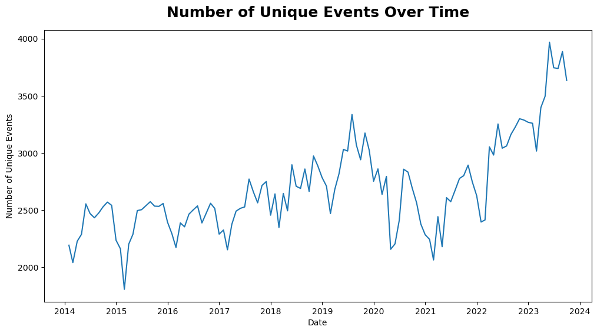

```python
import pandas as pd
import matplotlib.pyplot as plt
import seaborn as sns

# Convert date columns to datetime objects for better analysis
df['REPORT_DATE'] = pd.to_datetime(df['REPORT_DATE'])
df['OCC_DATE'] = pd.to_datetime(df['OCC_DATE'])


# Count the number of unique events per month
monthly_counts = df.resample('M', on='REPORT_DATE')['EVENT_UNIQUE_ID'].nunique()

# Plot the number of unique events over time
plt.figure(figsize=(12, 6))
sns.lineplot(x=monthly_counts.index, y=monthly_counts.values)
plt.title('Number of Unique Events Over Time',fontsize=18, fontweight='bold', y=1.03)
plt.xlabel('Date')
plt.ylabel('Number of Unique Events')
plt.show()
```

```python
# count of unique values in the 'MCI_CATEGORY' column
df.MCI_CATEGORY.value_counts()
```

```
Assault            191724
Break and Enter     67884
Auto Theft          55334
Robbery             33061
Theft Over          12073
Name: MCI_CATEGORY, dtype: int64
```

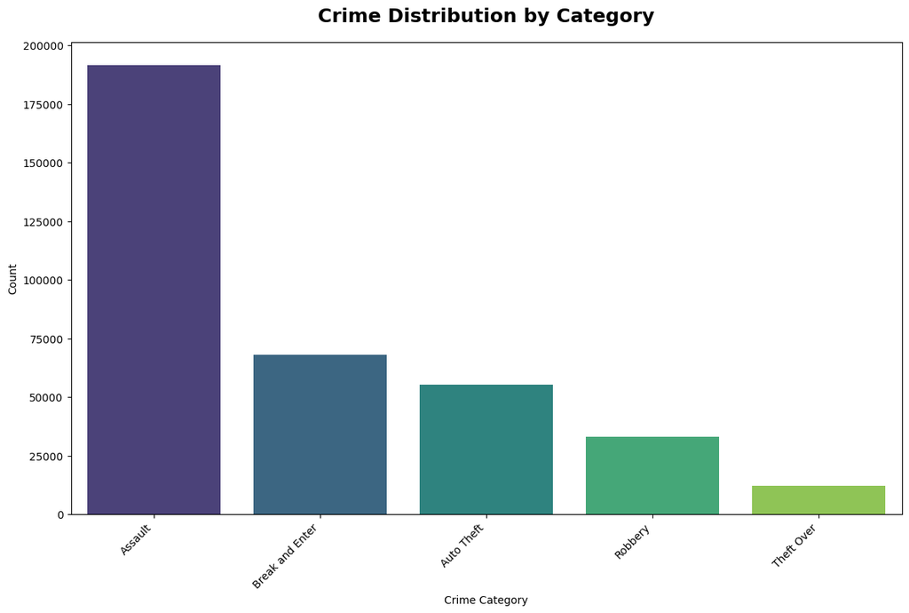

```python
import seaborn as sns
import matplotlib.pyplot as plt

# Plot the distribution of crimes by category
plt.figure(figsize=(14, 8))
sns.countplot(x='MCI_CATEGORY', data=df, order=df['MCI_CATEGORY'].value_counts().index, palette='viridis')
plt.title('Crime Distribution by Category',fontsize=18, fontweight='bold', y=1.03)
plt.xlabel('Crime Category')
plt.ylabel('Count')
plt.xticks(rotation=45, ha='right')  # Rotate x-axis labels for better visibility
plt.show()
```

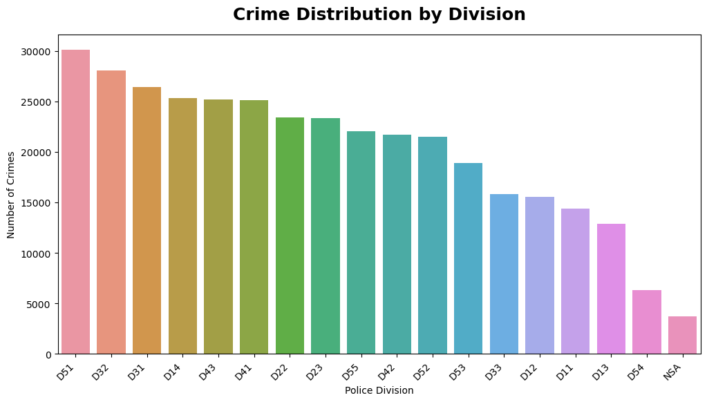

```python
import seaborn as sns
import matplotlib.pyplot as plt

# Bar plot for crime distribution by division
plt.figure(figsize=(12, 6))
sns.countplot(x='DIVISION', data=df, order=df['DIVISION'].value_counts().index)
plt.title('Crime Distribution by Division',fontsize=18, fontweight='bold', y=1.03)
plt.xlabel('Police Division')
plt.ylabel('Number of Crimes')
plt.xticks(rotation=45, ha='right')  # Rotate x-axis labels for better readability
plt.show()
```

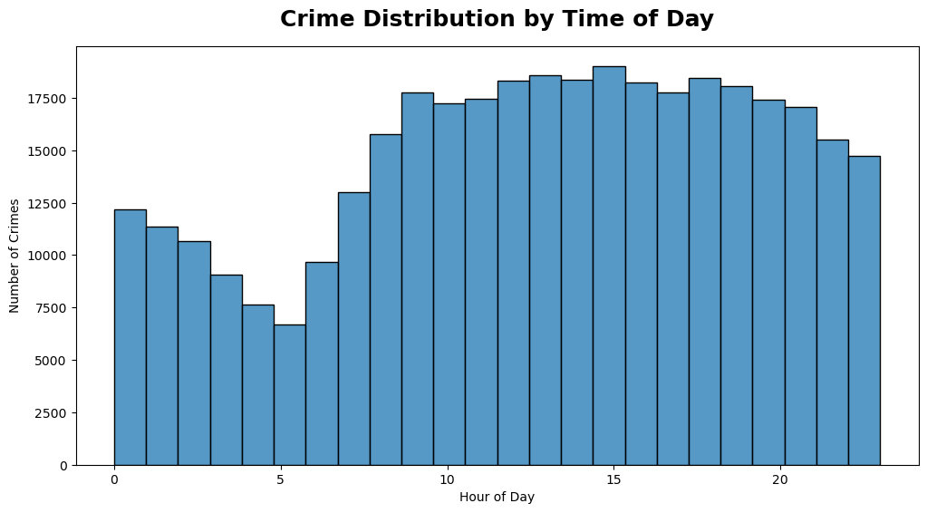

```python
import seaborn as sns
import matplotlib.pyplot as plt

# Histogram for crime distribution by hour
plt.figure(figsize=(12, 6))
sns.histplot(df['REPORT_HOUR'], bins=24, kde=False)
plt.title('Crime Distribution by Time of Day',fontsize=18, fontweight='bold', y=1.03)
plt.xlabel('Hour of Day')
plt.ylabel('Number of Crimes')
plt.show()
```

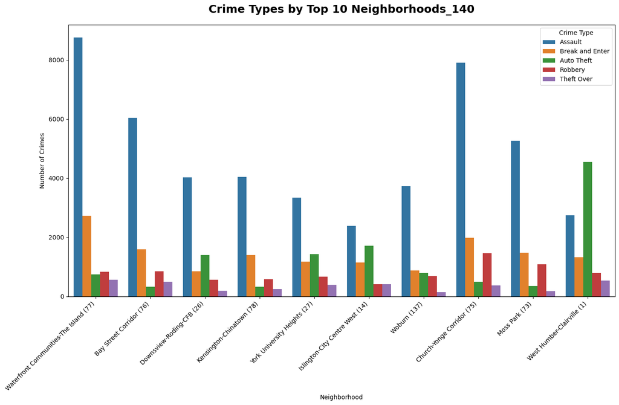

```python
import matplotlib.pyplot as plt
import seaborn as sns

# Get the top 10 neighborhoods based on the number of crimes
top_neighborhoods = df['NEIGHBOURHOOD_140'].value_counts().nlargest(10).index

# Filter the dataset for the top 10 neighborhoods
df_top_neighborhoods = df[df['NEIGHBOURHOOD_140'].isin(top_neighborhoods)]

# Plot the count of each crime category in the top 10 neighborhoods
plt.figure(figsize=(16, 8))
sns.countplot(x='NEIGHBOURHOOD_140', hue='MCI_CATEGORY', data=df_top_neighborhoods)
plt.title('Crime Types by Top 10 Neighborhoods_140',fontsize=18, fontweight='bold', y=1.03)
plt.xlabel('Neighborhood')
plt.ylabel('Number of Crimes')
plt.xticks(rotation=45, ha='right')  # Rotate x-axis labels for better readability
plt.legend(title='Crime Type', bbox_to_anchor=(1, 1))
plt.show()
```

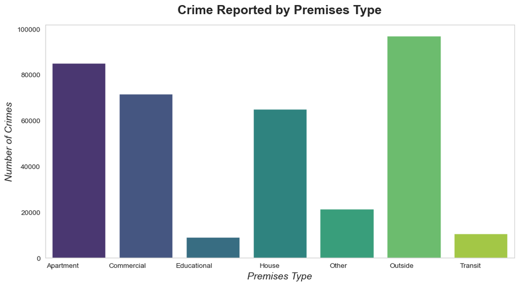

```python
# Group by premises type and count the number of crimes
df_premises = df.groupby('PREMISES_TYPE').size().reset_index(name='count')
df_premises = df_premises.rename(columns={'X': 'Count'})

# Bar graph for Premises type distribution
sns.set_style('whitegrid')
plt.figure(figsize=(12,6))
ax = sns.barplot(x='PREMISES_TYPE', y='count', data=df_premises, palette='viridis')
ax.set_xticklabels(ax.get_xticklabels(), ha='right')
ax.set_title('Crime Reported by Premises Type',fontsize=18, fontweight='bold', y=1.03)
ax.set_xlabel('Premises Type',fontsize=14, fontstyle='italic')
ax.set_ylabel('Number of Crimes',fontsize=14, fontstyle='italic')
ax.grid(False)
plt.show()
```

```
      OCC_DOW  count
0  Friday      54236
2  Saturday    53109
3  Sunday      51238
4  Thursday    50904
6  Wednesday   50732
1  Monday      50153
5  Tuesday     49704
```

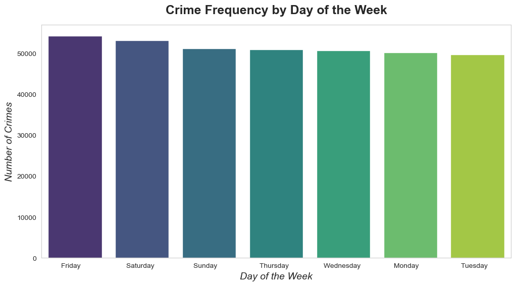

```python
#Check the count of occurrences during each day of the week
df_dayofweek = df.groupby('OCC_DOW').size().reset_index(name='count')
df_dayofweek = df_dayofweek.rename(columns={'X': 'count'})
df_dayofweek = df_dayofweek.sort_values(by='count', ascending=False)
print(df_dayofweek)

#Plot the count of occurrences during the week
sns.set_style('whitegrid')
plt.figure(figsize=(12,6))
ax = sns.barplot(x='OCC_DOW', y='count', data=df_dayofweek, palette='viridis')
ax.set_title('Crime Frequency by Day of the Week', fontsize=18, fontweight='bold', y=1.03)
ax.set_xlabel('Day of the Week',fontsize=14, fontstyle='italic')
ax.set_ylabel('Number of Crimes',fontsize=14, fontstyle='italic')
ax.grid(False)
plt.show()
```

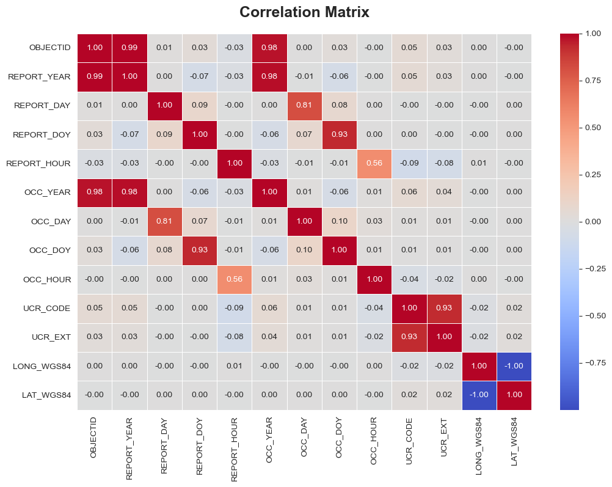

```python
import seaborn as sns
import matplotlib.pyplot as plt

# Select numerical columns for correlation analysis
numerical_cols = df.select_dtypes(include='number')

# Calculate correlation matrix
corr_matrix = numerical_cols.corr()

# Create a heatmap
plt.figure(figsize=(12, 8))
sns.heatmap(corr_matrix, annot=True, cmap='coolwarm', fmt='.2f', linewidths=0.5)
plt.title('Correlation Matrix',fontsize=18, fontweight='bold', y=1.03)
plt.show()
```